[figure not shown]

# Dr. Suat ATAN

Experiments on R, Python and Data Science

16 Jan 2020

# Syrian Refugee Crisis in Turkey

# News Analytics Report: Syrian Refugee Crisis in Turkey

Dr. Suat ATAN

29 09 2019

# Definition

Turkey now holds the world’s largest refugee population. According to a new World Bank Policy Brief, Turkey’s response to the Syrian Refugee Crisis and Road Ahead, the Turkish Government (GoT) puts the total number of registered Syrians under Temporary Protection (SuTPs) at 2,225,147 [^1].

In this preliminary analysis, I employed **text mining** tools. I collected **4056** news from various news outlets in Turkish about the **Syrians** by the special algorithm that I developed.

# Objection

I intend to understand what’s main themes of this news. Are they any insights about this news? News analytics based on text mining may provide a landscape of media perception of “Syrians” and of course main themes of stories about them.

# Tools and Techniques

- R Language
- RStudio IDE
- Web Scraping Libraries
- Text Mining libraries
- SQLite Database

# Number of news stories

```r
db_default_adres = "db/suriyeliler.sqlite"
text_df <- derlenen_tum_haber_basliklari_df(db_adres = db_default_adres)
nrow(text_df)
```

```
## [1] 4056
```

# Sources of News

Distribution of news among the news sources.

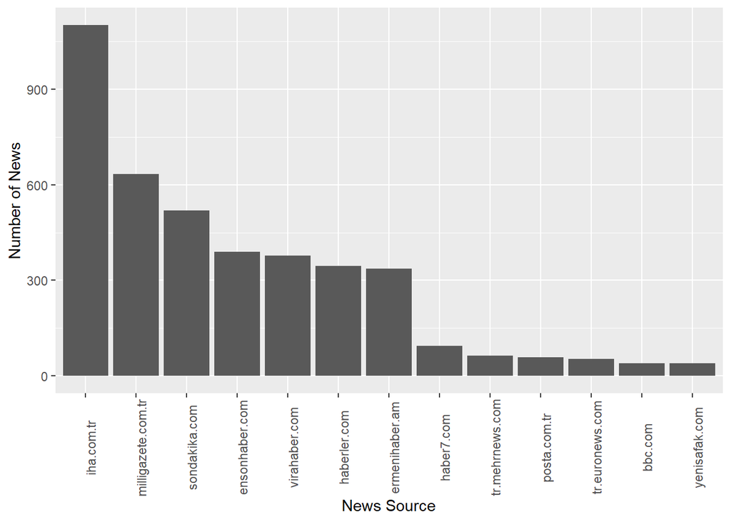

```r
il_il_haber <- sayfa_url_bazinda_haber_sayilarini_getir(db_adres = db_default_adres)
il_il_haber %>%
  ggplot(aes(x=reorder(sayfa_url,-n),y=n)) + geom_col()  +
  theme(axis.text.x = element_text(angle = 90)) +
  labs(x="News Source",y="Number of News")
```

# Most Common Terms in All News

```r
text_word <- basliklari_kelimelere_kir(text_df)
cok_gorulen_kelimeler <- derlenen_toplam_haberlerde_cok_gorulen_kelimeler(text_word)
cok_gorulen_kelimeler #%>% top_n(1000) %>% datatable()
```

```
## # A tibble: 295 x 2
##    kok         n
##    <fct>   <int>
##  1 suriyel  1151
##  2 göçme     662
##  3 kaçak     513
##  4 yakala    489
##  5 çocuk     373
##  6 iç        248
##  7 il        191
##  8 öldürül   170
##  9 savaş     169
## 10 ger       159
## # … with 285 more rows
```

# News Vocabulary

```r
nrow(cok_gorulen_kelimeler)
```

```
## [1] 295
```

# Re-Categorization of the Most Common Terms

# Diagram of Recategorized Terms

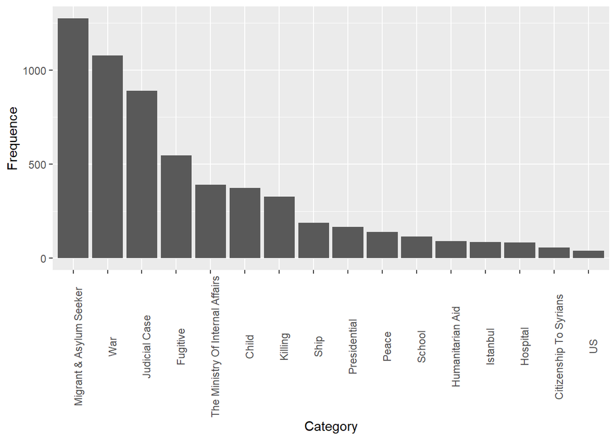

```r
# en sağa kategori adında başlık oluştur.
# x ile işaretlenen ilgisiz kategori ayıklanmıştır
duzeltilmis_data <- read.xlsx("config/duzeltilecek_data_suriyeliler.xlsx",sheetName = "Sheet1")
duzeltilmis_data %>%
  group_by(kategori) %>%
  summarise(nn = sum(n)) %>%
  arrange(desc(nn)) %>%
  filter(kategori != "x") %>%
  ggplot(aes(x=reorder(kategori,-nn),y=nn)) + geom_col()+ theme(axis.text.x = element_text(angle = 90)) +
  labs(x="Category",y="Frequence")
```

# Word Cloud

```r
library("wordcloud2")
cok_gorulen_kelimeler_buyuk <- derlenen_toplam_haberlerde_cok_gorulen_kelimeler(text_word,esik=15)
cok_gorulen_kelimelerden_kelime_bulutu_uret(cok_gorulen_kelimeler_buyuk, azami_kelime_adedi = 300)
```

[interactive chart not shown]

# Conclusion

Naturally, the two most common terms are about immigrants and asylum seekers and war. These keywords are deterministically connected because this crisis is the ramification of ‘war’. The third most common term is **Judicial Cases** and **Fugitive** Unfortunately there are tons of stories about murders, deads, fight, corpse, funeral, etc. This issue stems from the social integration problems of refugees. Other conspicuous terms in the list are:

- Child
- Ship
- School
- Humanitarian Aid
- Hospital
- Istanbul

These terms reflect the main themes of this humanitarian crisis. Although the efforts to alleviate the problem, the humanitarian crisis lasts and seems like it affects the **children**.

[^1]: https://www.worldbank.org/en/country/turkey/publication/turkeys-response-to-the-syrian-refugee-crisis-and-the-road-ahead
- news_analytics
- text_mining

[comments powered by Disqus](http://disqus.com/)